# ejercicio_clase4

#### 2) Teniendo en cuenta la variable COLEGIO se pide:

```r
colegio <- cuestionario$colegio

colegio[colegio == 1] <- "estatal"
colegio[colegio == 2] <- "privado no religioso"
colegio[colegio == 3] <- "privado religioso"

#colegio <- factor(colegio, labels = c("estatal", "privado no religioso", "privado religioso"))
```

• Qué porcentaje de individuos ha concurrido a un centro privado- no religioso? • Qué cantidad de individuos ha concurrido a un centro estatal?

```r
(prop.table(table(colegio))*100) %>%
  round(2)
```

```
## colegio
##              estatal privado no religioso    privado religioso
##                66.53                 8.26                25.21
```

• Realizar el gráfico adecuado que muestre los porcentajes de individuos que han concurrido a los diferentes centros educativos.

- Barplot():

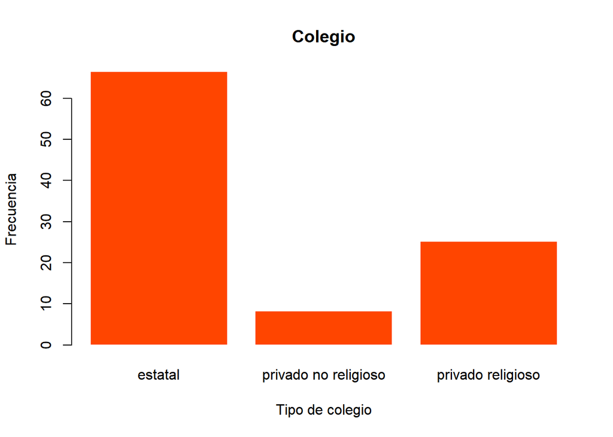

```
##      [,1]
## [1,]  0.7
## [2,]  1.9
## [3,]  3.1
```

```r
barplot((prop.table(table(colegio))*100),
          main = "Colegio",
          ylab = "Frecuencia",
          xlab = 'Tipo de colegio',
          col = ("orangered1"),
          border = FALSE) %>%
          round(2)
```

- Ggplot() + geom_bar():

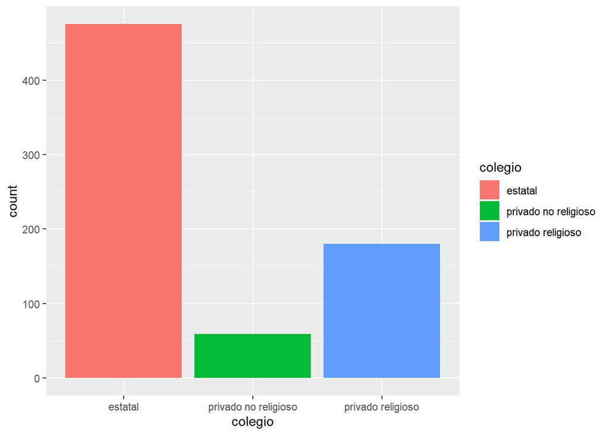

```r
#Si quiero quitarle los NA:
cuestionario <- cuestionario %>%
    filter(!is.na(colegio))

cuestionario$colegio[cuestionario$colegio == 1] <- "estatal"
cuestionario$colegio[cuestionario$colegio == 2] <- "privado no religioso"
cuestionario$colegio[cuestionario$colegio == 3] <- "privado religioso"

ggplot(cuestionario, aes(colegio, fill = colegio)) +
    geom_bar()
```

#### 3) Elaborar la distribución de frecuencias de la variable AMOR.

```r
amor <- cuestionario$amor

cuestionario$amor[cuestionario$amor == 1] <- "de novio"
cuestionario$amor[cuestionario$amor == 2] <- "ahora sin pareja"
cuestionario$amor[cuestionario$amor == 3] <- "solo rel pasajeras"
cuestionario$amor[cuestionario$amor == 4] <- "nunca relacion"

#amor <- factor(amor, labels = c("de novio", "ahora sin pareja", "solo rel pasajeras", "nunca relacion"))
```

• Qué porcentaje de los individuos nunca ha tenido una relación afectiva especial? • Cuántos individuos han manifestado haber tenido hasta ahora relaciones afectivas pasajeras?

```r
addmargins((prop.table(table(amor)))*100) %>%
      round(2)
```

```
## amor
##      1      2      3      4    Sum
##  45.44  21.33  22.72  10.51 100.00
```

• Realizar el gráfico adecuado para esta variable, indicando en él los porcentajes de cada categoría.

- Barplot()

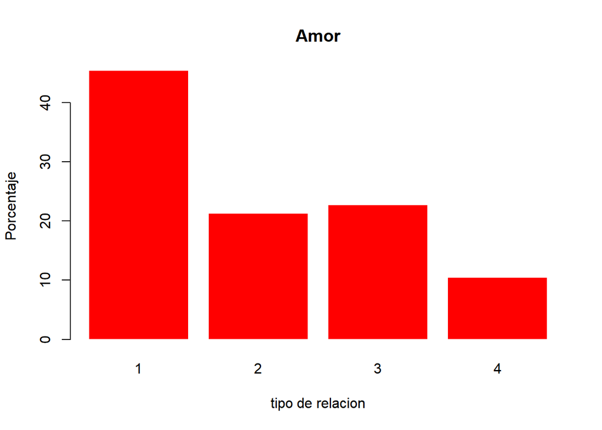

```
##      [,1]
## [1,]  0.7
## [2,]  1.9
## [3,]  3.1
## [4,]  4.3
```

```r
barplot((prop.table(table(amor))*100),
        main = "Amor",
        ylab = "Porcentaje",
        xlab = "tipo de relacion",
        col =  "red",
        border = FALSE)%>%
        round(2)
```

- ggplot() + geom_bar():

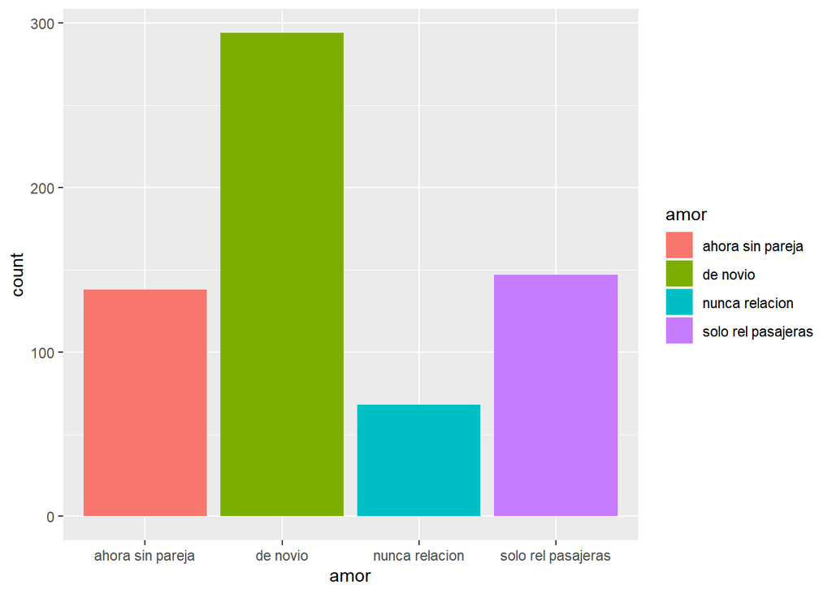

```r
cuestionario <- cuestionario %>%
                filter(!is.na(amor))


cuestionario$amor[cuestionario$amor == 1] <- "de novio"
cuestionario$amor[cuestionario$amor == 2] <- "ahora sin pareja"
cuestionario$amor[cuestionario$amor == 3] <- "solo rel pasajeras"
cuestionario$amor[cuestionario$amor == 4] <- "nunca relacion"

ggplot(cuestionario, aes(amor, fill = amor))+
  geom_bar()
```